# Is chooseGCM affected by variable selection?

This Rmarkdown is part of the following article:

Esser, L.F., Bailly, D., Lima, M.R., Ré, R. 2024. chooseGCM: a toolkit to select General Circulation Models in R. *In prep*.

## Introduction

chooseGCM is a solution for GCMs selection in Climate Change research. We built this Rmarkdown as a way to test the properties of the methods underlying chooseGCM. Results from each function will be presented side by side with changing variables, allowing better comparison. Here, we have already downloaded GCMs data.

This Rmarkdown will apply different algorithms implemented in chooseGCM in different variables sets. The aim is to understand if different variables sets will affect the GCMs subset selected by algorithms. We expect that results will change with varibles sets, since this change will change the very core of the comparison process, which is values presented. To showcase this, we used four sets of bioclimatic variables: (1) Bio1 and Bio12, which are the main temperature and precipitation variables (Annual Mean Temperature and Annual Precipitation, respectively); (2) Temperature variables (Bio1 to Bio11); (3) Precipitation variables (Bio12 to Bio19); and (4) all bioclimatic variables.

```r
# Install and open CRAN libraries
for(x in c("devtools", "geodata", "terra", "tictoc") ){
  if (!require(x, character.only = TRUE)) {
      install.packages(x, dependencies = TRUE)
      library(x, character.only = TRUE)
  }
}

# Install and open chooseGCM
if (!require("chooseGCM", character.only = TRUE)) {
    devtools::install_github("luizesser/chooseGCM")
    library("chooseGCM", character.only = TRUE)
}

# Install and open caretSDM
if (!require("caretSDM", character.only = TRUE)) {
    devtools::install_github("luizesser/caretSDM")
    library("caretSDM", character.only = TRUE)
}
```

## Preparing data

### Import study_area

For this demonstration, we will use Araucaria angustifolia, the brazilian pine, as a study case. This flagship species is a key species for the Atlantic Rainforest biodiversity hotspot. Species records were obtained from GBIF and cleaned by excluding records from outside the native region and NAs. This set of records was then used to build a shape of accessible area by merging buffers of 500 km around each record.

```r
occ_data <- geodata::sp_occurrence("Araucaria", "angustifolia")
```

```
## 1932 records found
```

```
## 0-300-600-900-1200-1500-1800-1932
## 1932 records downloaded
```

```r
occ_data <- occ_data |>
  dplyr::filter(lon >= -64) |>
  dplyr::filter(lon <= -33) |>
  dplyr::filter(lat <= -19.5) |>
  dplyr::filter(lat >= -33)

study_area <- na.omit(occ_data[,c("lon", "lat")]) |>
  sf::st_as_sf(coords= c(1,2), crs = 4326) |>
  sf::st_transform(crs=sf::st_crs(6933)) |>
  sf::st_buffer(dist = 500000) |>
  sf::st_union()
```

### Download GCMs

To obtain GCMs data, we recommend using `geodata` package, which links directly to the WorldClim 2.1 database. We have previously downloaded GCMs data, but an example code is supplied below.

```r
gcms <- geodata:::.cmods
for (r in c(10)) {
  for ( g in gcms ) {
    geodata::cmip6_world(model = g,
                         ssp = "585",
                         time = "2081-2100",
                         var = "bioc",
                         res = r,
                         path = ""
    )
  }
}
```

### Import GCMs

The function `import_gcms` helps the user to import data in the correct way, which is a list of GCMs. Each element of the list is a `SpatRaster` from `terra` package, containing all variables. The list should be named with GCMs names to better plot results.

```r
tictoc::tic()
s10 <- chooseGCM::import_gcms(path = "~/storage/WC_data/WC_data_all_gcms_10/",
                              gcm_names = c("ACCESS-CM2","ACCESS-ESM1-5",
                                            "CanESM5-CanOE","CMCC-ESM2",
                                            "CNRM-CM6-1-HR","CNRM-CM6-1",
                                            "CNRM-ESM2-1","EC-Earth3-Veg",
                                            "EC-Earth3-Veg-LR","FIO-ESM-2-0",
                                            "GISS-E2-1-G","GISS-E2-1-H",
                                            "HadGEM3-GC31-LL","INM-CM5-0",
                                            "INM-CM4-8","IPSL-CM6A-LR",
                                            "MIROC-ES2L","MIROC6",
                                            "MPI-ESM1-2-LR","MPI-ESM1-2-HR",
                                            "MRI-ESM2-0","UKESM1-0-LL"))
tictoc::toc()
```

```
## 0.165 sec elapsed
```

## Applying algorithms

First we will set a seed to standardize randomic outputs.

```r
set.seed(1)
```

Now we will perform the Monte Carlo analysis to each type of algorithm and to different sets of variables.

### Hierarchical Clustering selection

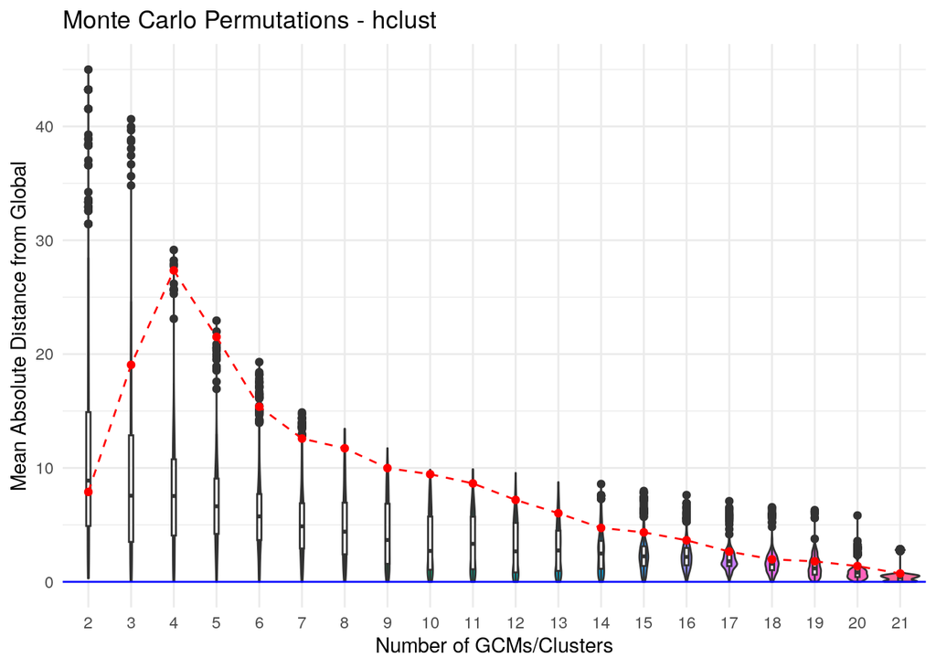

```
##
## $suggested_gcms
## $suggested_gcms$k2
## [1] "ACCESS-ESM1-5"    "EC-Earth3-Veg-LR"
##
## $suggested_gcms$k3
## [1] "ACCESS-ESM1-5"    "EC-Earth3-Veg-LR" "MPI-ESM1-2-HR"
##
## $suggested_gcms$k4
## [1] "ACCESS-ESM1-5"    "CanESM5-CanOE"    "EC-Earth3-Veg-LR" "MPI-ESM1-2-HR"
##
## $suggested_gcms$k5
## [1] "ACCESS-ESM1-5"    "CanESM5-CanOE"    "CMCC-ESM2"        "EC-Earth3-Veg-LR"
## [5] "MPI-ESM1-2-HR"
##
## $suggested_gcms$k6
## [1] "ACCESS-ESM1-5"    "CanESM5-CanOE"    "CMCC-ESM2"        "EC-Earth3-Veg-LR"
## [5] "MPI-ESM1-2-LR"    "MPI-ESM1-2-HR"
##
## $suggested_gcms$k7
## [1] "ACCESS-ESM1-5"    "CanESM5-CanOE"    "CMCC-ESM2"        "INM-CM4-8"
## [5] "EC-Earth3-Veg-LR" "MPI-ESM1-2-LR"    "MPI-ESM1-2-HR"
##
## $suggested_gcms$k8
## [1] "ACCESS-ESM1-5"    "CanESM5-CanOE"    "CMCC-ESM2"        "INM-CM4-8"
## [5] "EC-Earth3-Veg-LR" "GISS-E2-1-H"      "MPI-ESM1-2-LR"    "MPI-ESM1-2-HR"
##
## $suggested_gcms$k9
## [1] "ACCESS-ESM1-5"    "CanESM5-CanOE"    "CMCC-ESM2"        "INM-CM4-8"
## [5] "CNRM-CM6-1-HR"    "EC-Earth3-Veg-LR" "GISS-E2-1-H"      "MPI-ESM1-2-LR"
## [9] "MPI-ESM1-2-HR"
##
## $suggested_gcms$k10
##  [1] "ACCESS-CM2"       "ACCESS-ESM1-5"    "CanESM5-CanOE"    "CMCC-ESM2"
##  [5] "INM-CM4-8"        "CNRM-CM6-1-HR"    "EC-Earth3-Veg-LR" "GISS-E2-1-H"
##  [9] "MPI-ESM1-2-LR"    "MPI-ESM1-2-HR"
##
## $suggested_gcms$k11
##  [1] "ACCESS-CM2"       "ACCESS-ESM1-5"    "CanESM5-CanOE"    "CMCC-ESM2"
##  [5] "INM-CM4-8"        "CNRM-CM6-1-HR"    "EC-Earth3-Veg-LR" "GISS-E2-1-H"
```

[output cut: 51 more lines]

```
##
## $suggested_gcms$k20
##  [1] "ACCESS-CM2"       "ACCESS-ESM1-5"    "CanESM5-CanOE"    "CMCC-ESM2"
##  [5] "CNRM-CM6-1"       "CNRM-CM6-1-HR"    "EC-Earth3-Veg"    "EC-Earth3-Veg-LR"
##  [9] "FIO-ESM-2-0"      "GISS-E2-1-G"      "GISS-E2-1-H"      "HadGEM3-GC31-LL"
## [13] "INM-CM4-8"        "INM-CM5-0"        "IPSL-CM6A-LR"     "MIROC-ES2L"
## [17] "MIROC6"           "MPI-ESM1-2-HR"    "MPI-ESM1-2-LR"    "MRI-ESM2-0"
##
## $suggested_gcms$k21
##  [1] "ACCESS-CM2"       "ACCESS-ESM1-5"    "CanESM5-CanOE"    "CMCC-ESM2"
##  [5] "CNRM-CM6-1"       "CNRM-CM6-1-HR"    "EC-Earth3-Veg"    "EC-Earth3-Veg-LR"
##  [9] "FIO-ESM-2-0"      "GISS-E2-1-G"      "GISS-E2-1-H"      "HadGEM3-GC31-LL"
## [13] "INM-CM4-8"        "INM-CM5-0"        "IPSL-CM6A-LR"     "MIROC-ES2L"
## [17] "MIROC6"           "MPI-ESM1-2-HR"    "MPI-ESM1-2-LR"    "MRI-ESM2-0"
## [21] "UKESM1-0-LL"
```

```r
tictoc::tic("Hierarchical Clustering Main Bioclimatics")
mc_hclust_main <- montecarlo_gcms(s10,
                             var_names = c("bio1", "bio12"),
                             study_area = study_area,
                             scale = TRUE,
                             perm = 10000,
                             dist_method = "euclidean",
                             clustering_method = "hclust")
mc_hclust_main
```

```r
hclust_main <- mc_hclust_main$suggested_gcms$k5
tictoc::toc()
```

```
## Hierarchical Clustering Main Bioclimatics: 15.834 sec elapsed
```

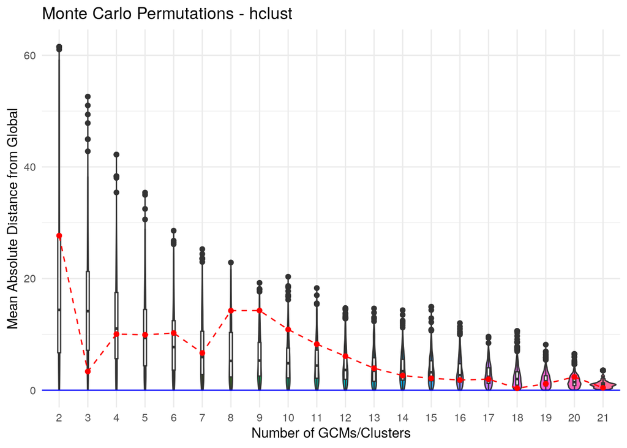

```
##
## $suggested_gcms
## $suggested_gcms$k2
## [1] "EC-Earth3-Veg-LR" "FIO-ESM-2-0"
##
## $suggested_gcms$k3
## [1] "ACCESS-CM2"       "FIO-ESM-2-0"      "EC-Earth3-Veg-LR"
##
## $suggested_gcms$k4
## [1] "ACCESS-CM2"       "FIO-ESM-2-0"      "EC-Earth3-Veg-LR" "GISS-E2-1-H"
##
## $suggested_gcms$k5
## [1] "ACCESS-CM2"       "CMCC-ESM2"        "FIO-ESM-2-0"      "EC-Earth3-Veg-LR"
## [5] "GISS-E2-1-H"
##
## $suggested_gcms$k6
## [1] "ACCESS-CM2"       "CMCC-ESM2"        "CNRM-CM6-1"       "EC-Earth3-Veg-LR"
## [5] "FIO-ESM-2-0"      "GISS-E2-1-H"
##
## $suggested_gcms$k7
## [1] "ACCESS-CM2"       "CMCC-ESM2"        "CNRM-CM6-1"       "EC-Earth3-Veg-LR"
## [5] "FIO-ESM-2-0"      "GISS-E2-1-H"      "INM-CM4-8"
##
## $suggested_gcms$k8
## [1] "ACCESS-CM2"       "CanESM5-CanOE"    "CMCC-ESM2"        "CNRM-CM6-1"
## [5] "EC-Earth3-Veg-LR" "FIO-ESM-2-0"      "GISS-E2-1-H"      "INM-CM4-8"
##
## $suggested_gcms$k9
## [1] "ACCESS-CM2"       "CanESM5-CanOE"    "CMCC-ESM2"        "CNRM-CM6-1"
## [5] "EC-Earth3-Veg-LR" "FIO-ESM-2-0"      "GISS-E2-1-H"      "INM-CM4-8"
## [9] "MPI-ESM1-2-HR"
##
## $suggested_gcms$k10
##  [1] "ACCESS-CM2"       "CanESM5-CanOE"    "CMCC-ESM2"        "CNRM-CM6-1"
##  [5] "EC-Earth3-Veg-LR" "FIO-ESM-2-0"      "GISS-E2-1-H"      "INM-CM4-8"
##  [9] "MIROC-ES2L"       "MPI-ESM1-2-HR"
##
## $suggested_gcms$k11
##  [1] "ACCESS-CM2"       "CanESM5-CanOE"    "CMCC-ESM2"        "CNRM-CM6-1"
##  [5] "EC-Earth3-Veg-LR" "FIO-ESM-2-0"      "GISS-E2-1-H"      "HadGEM3-GC31-LL"
```

[output cut: 51 more lines]

```
##
## $suggested_gcms$k20
##  [1] "ACCESS-CM2"       "ACCESS-ESM1-5"    "CanESM5-CanOE"    "CMCC-ESM2"
##  [5] "CNRM-CM6-1"       "CNRM-CM6-1-HR"    "CNRM-ESM2-1"      "EC-Earth3-Veg-LR"
##  [9] "FIO-ESM-2-0"      "GISS-E2-1-G"      "GISS-E2-1-H"      "HadGEM3-GC31-LL"
## [13] "INM-CM4-8"        "INM-CM5-0"        "IPSL-CM6A-LR"     "MIROC-ES2L"
## [17] "MIROC6"           "MPI-ESM1-2-HR"    "MPI-ESM1-2-LR"    "MRI-ESM2-0"
##
## $suggested_gcms$k21
##  [1] "ACCESS-CM2"       "ACCESS-ESM1-5"    "CanESM5-CanOE"    "CMCC-ESM2"
##  [5] "CNRM-CM6-1"       "CNRM-CM6-1-HR"    "CNRM-ESM2-1"      "EC-Earth3-Veg"
##  [9] "EC-Earth3-Veg-LR" "FIO-ESM-2-0"      "GISS-E2-1-G"      "GISS-E2-1-H"
## [13] "HadGEM3-GC31-LL"  "INM-CM4-8"        "INM-CM5-0"        "IPSL-CM6A-LR"
## [17] "MIROC-ES2L"       "MIROC6"           "MPI-ESM1-2-HR"    "MPI-ESM1-2-LR"
## [21] "MRI-ESM2-0"
```

```r
tictoc::tic("Hierarchical Clustering Temperature Variables")
mc_hclust_temp <- montecarlo_gcms(s10,
                             var_names = c("bio1", "bio2", "bio3", "bio4", "bio5", "bio6", "bio7", "bio8", "bio9", "bio10", "bio11"),
                             study_area = study_area,
                             scale = TRUE,
                             perm = 10000,
                             dist_method = "euclidean",
                             clustering_method = "hclust")
mc_hclust_temp
```

```r
hclust_temp <- mc_hclust_temp$suggested_gcms$k5
tictoc::toc()
```

```
## Hierarchical Clustering Temperature Variables: 24.27 sec elapsed
```

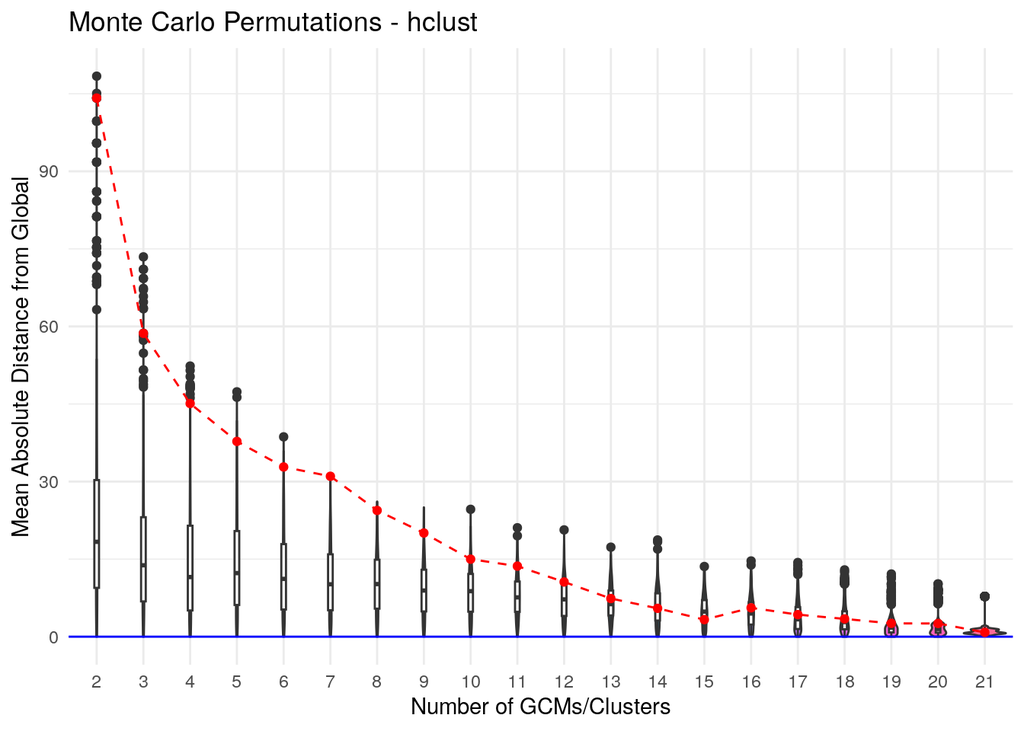

```
##
## $suggested_gcms
## $suggested_gcms$k2
## [1] "GISS-E2-1-G"   "CanESM5-CanOE"
##
## $suggested_gcms$k3
## [1] "MRI-ESM2-0"    "CanESM5-CanOE" "GISS-E2-1-G"
##
## $suggested_gcms$k4
## [1] "MRI-ESM2-0"    "CanESM5-CanOE" "CMCC-ESM2"     "GISS-E2-1-G"
##
## $suggested_gcms$k5
## [1] "MRI-ESM2-0"    "CanESM5-CanOE" "CMCC-ESM2"     "CNRM-CM6-1"
## [5] "GISS-E2-1-G"
##
## $suggested_gcms$k6
## [1] "MRI-ESM2-0"       "CanESM5-CanOE"    "CMCC-ESM2"        "CNRM-CM6-1"
## [5] "EC-Earth3-Veg-LR" "GISS-E2-1-G"
##
## $suggested_gcms$k7
## [1] "MRI-ESM2-0"       "CanESM5-CanOE"    "CMCC-ESM2"        "CNRM-CM6-1"
## [5] "EC-Earth3-Veg-LR" "GISS-E2-1-G"      "MPI-ESM1-2-HR"
##
## $suggested_gcms$k8
## [1] "MRI-ESM2-0"       "CanESM5-CanOE"    "CMCC-ESM2"        "CNRM-CM6-1"
## [5] "EC-Earth3-Veg-LR" "GISS-E2-1-G"      "INM-CM5-0"        "MPI-ESM1-2-HR"
##
## $suggested_gcms$k9
## [1] "MRI-ESM2-0"       "ACCESS-ESM1-5"    "CanESM5-CanOE"    "CMCC-ESM2"
## [5] "CNRM-CM6-1"       "EC-Earth3-Veg-LR" "GISS-E2-1-G"      "INM-CM5-0"
## [9] "MPI-ESM1-2-HR"
##
## $suggested_gcms$k10
##  [1] "MRI-ESM2-0"       "ACCESS-ESM1-5"    "CanESM5-CanOE"    "CMCC-ESM2"
##  [5] "CNRM-CM6-1"       "EC-Earth3-Veg-LR" "GISS-E2-1-G"      "INM-CM5-0"
##  [9] "MIROC6"           "MPI-ESM1-2-HR"
##
## $suggested_gcms$k11
##  [1] "MRI-ESM2-0"       "ACCESS-ESM1-5"    "CanESM5-CanOE"    "CMCC-ESM2"
##  [5] "CNRM-CM6-1"       "EC-Earth3-Veg-LR" "GISS-E2-1-G"      "INM-CM5-0"
```

[output cut: 51 more lines]

```
##
## $suggested_gcms$k20
##  [1] "ACCESS-CM2"       "ACCESS-ESM1-5"    "CanESM5-CanOE"    "CMCC-ESM2"
##  [5] "CNRM-CM6-1"       "CNRM-CM6-1-HR"    "CNRM-ESM2-1"      "EC-Earth3-Veg"
##  [9] "EC-Earth3-Veg-LR" "FIO-ESM-2-0"      "GISS-E2-1-G"      "GISS-E2-1-H"
## [13] "UKESM1-0-LL"      "INM-CM4-8"        "INM-CM5-0"        "IPSL-CM6A-LR"
## [17] "MIROC6"           "MPI-ESM1-2-HR"    "MPI-ESM1-2-LR"    "MRI-ESM2-0"
##
## $suggested_gcms$k21
##  [1] "ACCESS-CM2"       "ACCESS-ESM1-5"    "CanESM5-CanOE"    "CMCC-ESM2"
##  [5] "CNRM-CM6-1"       "CNRM-CM6-1-HR"    "CNRM-ESM2-1"      "EC-Earth3-Veg"
##  [9] "EC-Earth3-Veg-LR" "FIO-ESM-2-0"      "GISS-E2-1-G"      "GISS-E2-1-H"
## [13] "HadGEM3-GC31-LL"  "INM-CM4-8"        "INM-CM5-0"        "IPSL-CM6A-LR"
## [17] "MIROC6"           "MPI-ESM1-2-HR"    "MPI-ESM1-2-LR"    "MRI-ESM2-0"
## [21] "UKESM1-0-LL"
```

```r
tictoc::tic("Hierarchical Clustering Precipitation Variables")
mc_hclust_prec <- montecarlo_gcms(s10,
                             var_names = c("bio12", "bio13", "bio14", "bio15", "bio16", "bio17", "bio18", "bio19"),
                             study_area = study_area,
                             scale = TRUE,
                             perm = 10000,
                             dist_method = "euclidean",
                             clustering_method = "hclust")
mc_hclust_prec
```

```r
hclust_prec <- mc_hclust_prec$suggested_gcms$k5
tictoc::toc()
```

```
## Hierarchical Clustering Precipitation Variables: 17.778 sec elapsed
```

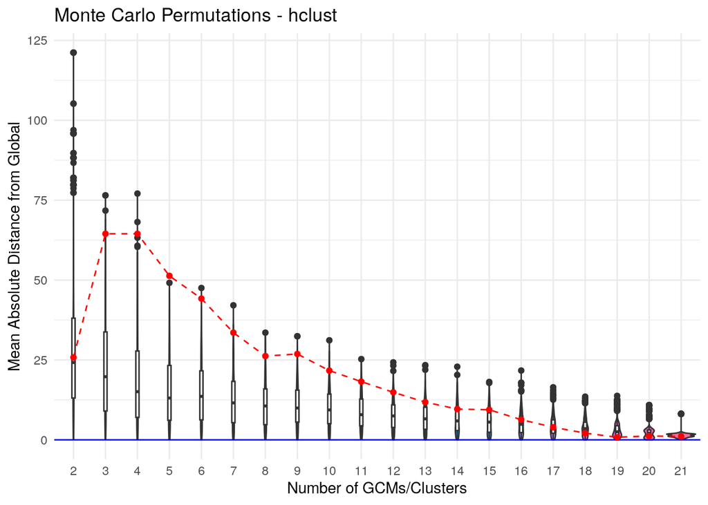

```
##
## $suggested_gcms
## $suggested_gcms$k2
## [1] "FIO-ESM-2-0"      "EC-Earth3-Veg-LR"
##
## $suggested_gcms$k3
## [1] "FIO-ESM-2-0"      "EC-Earth3-Veg-LR" "CanESM5-CanOE"
##
## $suggested_gcms$k4
## [1] "FIO-ESM-2-0"      "EC-Earth3-Veg-LR" "CanESM5-CanOE"    "GISS-E2-1-H"
##
## $suggested_gcms$k5
## [1] "FIO-ESM-2-0"      "EC-Earth3-Veg-LR" "CanESM5-CanOE"    "CNRM-CM6-1"
## [5] "GISS-E2-1-H"
##
## $suggested_gcms$k6
## [1] "FIO-ESM-2-0"      "CMCC-ESM2"        "CanESM5-CanOE"    "CNRM-CM6-1"
## [5] "EC-Earth3-Veg-LR" "GISS-E2-1-H"
##
## $suggested_gcms$k7
## [1] "FIO-ESM-2-0"      "HadGEM3-GC31-LL"  "CanESM5-CanOE"    "CMCC-ESM2"
## [5] "CNRM-CM6-1"       "EC-Earth3-Veg-LR" "GISS-E2-1-H"
##
## $suggested_gcms$k8
## [1] "FIO-ESM-2-0"      "HadGEM3-GC31-LL"  "CanESM5-CanOE"    "CMCC-ESM2"
## [5] "CNRM-CM6-1"       "EC-Earth3-Veg-LR" "GISS-E2-1-H"      "INM-CM4-8"
##
## $suggested_gcms$k9
## [1] "FIO-ESM-2-0"      "HadGEM3-GC31-LL"  "CanESM5-CanOE"    "CMCC-ESM2"
## [5] "CNRM-CM6-1"       "EC-Earth3-Veg-LR" "GISS-E2-1-H"      "INM-CM4-8"
## [9] "MPI-ESM1-2-HR"
##
## $suggested_gcms$k10
##  [1] "FIO-ESM-2-0"      "HadGEM3-GC31-LL"  "CanESM5-CanOE"    "CMCC-ESM2"
##  [5] "CNRM-CM6-1"       "EC-Earth3-Veg-LR" "GISS-E2-1-H"      "INM-CM4-8"
##  [9] "MIROC-ES2L"       "MPI-ESM1-2-HR"
##
## $suggested_gcms$k11
##  [1] "FIO-ESM-2-0"      "HadGEM3-GC31-LL"  "CanESM5-CanOE"    "CMCC-ESM2"
##  [5] "CNRM-CM6-1"       "EC-Earth3-Veg-LR" "GISS-E2-1-H"      "INM-CM4-8"
```

[output cut: 51 more lines]

```
##
## $suggested_gcms$k20
##  [1] "ACCESS-CM2"       "ACCESS-ESM1-5"    "CanESM5-CanOE"    "CMCC-ESM2"
##  [5] "CNRM-CM6-1"       "CNRM-CM6-1-HR"    "CNRM-ESM2-1"      "EC-Earth3-Veg-LR"
##  [9] "FIO-ESM-2-0"      "GISS-E2-1-G"      "GISS-E2-1-H"      "HadGEM3-GC31-LL"
## [13] "INM-CM4-8"        "INM-CM5-0"        "IPSL-CM6A-LR"     "MIROC-ES2L"
## [17] "MIROC6"           "MPI-ESM1-2-HR"    "MPI-ESM1-2-LR"    "MRI-ESM2-0"
##
## $suggested_gcms$k21
##  [1] "ACCESS-CM2"       "ACCESS-ESM1-5"    "CanESM5-CanOE"    "CMCC-ESM2"
##  [5] "CNRM-CM6-1"       "CNRM-CM6-1-HR"    "CNRM-ESM2-1"      "EC-Earth3-Veg"
##  [9] "EC-Earth3-Veg-LR" "FIO-ESM-2-0"      "GISS-E2-1-G"      "GISS-E2-1-H"
## [13] "HadGEM3-GC31-LL"  "INM-CM4-8"        "INM-CM5-0"        "IPSL-CM6A-LR"
## [17] "MIROC-ES2L"       "MIROC6"           "MPI-ESM1-2-HR"    "MPI-ESM1-2-LR"
## [21] "MRI-ESM2-0"
```

```r
tictoc::tic("Hierarchical Clustering All Variables")
mc_hclust_all <- montecarlo_gcms(s10,
                             var_names = "all",
                             study_area = study_area,
                             scale = TRUE,
                             perm = 10000,
                             dist_method = "euclidean",
                             clustering_method = "hclust")
mc_hclust_all
```

```r
hclust_all <- mc_hclust_all$suggested_gcms$k5
tictoc::toc()
```

```
## Hierarchical Clustering All Variables: 33.543 sec elapsed
```

### Kmeans selection

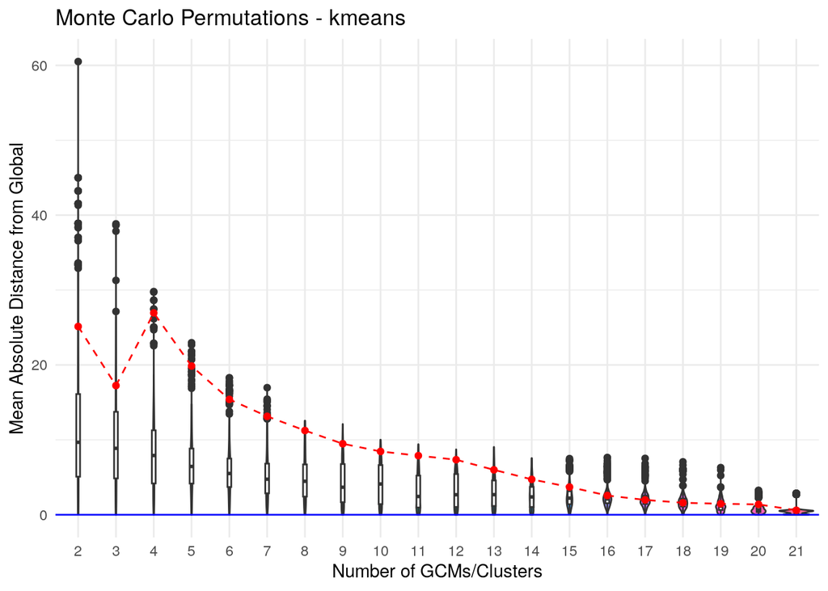

```
##
## $suggested_gcms
## $suggested_gcms$k2
##               1               2
##   "CNRM-ESM2-1" "CanESM5-CanOE"
##
## $suggested_gcms$k3
##               1               2               3
##    "MRI-ESM2-0"   "CNRM-ESM2-1" "CanESM5-CanOE"
##
## $suggested_gcms$k4
##               1               2               3               4
## "CanESM5-CanOE"    "MRI-ESM2-0"   "CNRM-ESM2-1" "MPI-ESM1-2-HR"
##
## $suggested_gcms$k5
##               1               2               3               4               5
##   "UKESM1-0-LL" "CanESM5-CanOE"    "MRI-ESM2-0" "MPI-ESM1-2-HR"    "CNRM-CM6-1"
##
## $suggested_gcms$k6
##               1               2               3               4               5
## "MPI-ESM1-2-HR" "CanESM5-CanOE"     "INM-CM4-8"   "UKESM1-0-LL"    "MRI-ESM2-0"
##               6
## "EC-Earth3-Veg"
##
## $suggested_gcms$k7
##               1               2               3               4               5
##   "FIO-ESM-2-0" "MPI-ESM1-2-HR"   "UKESM1-0-LL"    "MRI-ESM2-0" "CanESM5-CanOE"
##               6               7
##     "INM-CM4-8" "EC-Earth3-Veg"
##
## $suggested_gcms$k8
##               1               2               3               4               5
## "MPI-ESM1-2-HR"    "MIROC-ES2L" "EC-Earth3-Veg"   "GISS-E2-1-G"   "UKESM1-0-LL"
##               6               7               8
##     "INM-CM4-8"   "FIO-ESM-2-0" "CanESM5-CanOE"
##
## $suggested_gcms$k9
##               1               2               3               4               5
##    "MIROC-ES2L"   "GISS-E2-1-G"   "FIO-ESM-2-0" "MPI-ESM1-2-HR"   "CNRM-ESM2-1"
##               6               7               8               9
```

[output cut: 104 more lines]

```
##      "GISS-E2-1-G"       "ACCESS-CM2" "EC-Earth3-Veg-LR"       "MRI-ESM2-0"
##
## $suggested_gcms$k21
##                  1                  2                  3                  4
##        "CMCC-ESM2"      "CNRM-ESM2-1"       "CNRM-CM6-1"        "INM-CM5-0"
##                  5                  6                  7                  8
##       "MRI-ESM2-0"    "MPI-ESM1-2-LR"    "CanESM5-CanOE"    "EC-Earth3-Veg"
##                  9                 10                 11                 12
##       "MIROC-ES2L"    "ACCESS-ESM1-5"           "MIROC6"      "FIO-ESM-2-0"
##                 13                 14                 15                 16
##    "CNRM-CM6-1-HR"       "ACCESS-CM2"  "HadGEM3-GC31-LL"      "GISS-E2-1-H"
##                 17                 18                 19                 20
##    "MPI-ESM1-2-HR"      "GISS-E2-1-G"        "INM-CM4-8" "EC-Earth3-Veg-LR"
##                 21
##     "IPSL-CM6A-LR"
```

```r
tictoc::tic("K-means Clustering Main Variables")
mc_kmeans_main <- montecarlo_gcms(s10,
                             var_names = c("bio1", "bio12"),
                             study_area = study_area,
                             scale = TRUE,
                             perm = 10000,
                             dist_method = "euclidean",
                             clustering_method = "kmeans")
mc_kmeans_main
```

```r
kmeans_main <- mc_kmeans_main$suggested_gcms$k5
tictoc::toc()
```

```
## K-means Clustering Main Variables: 23.375 sec elapsed
```

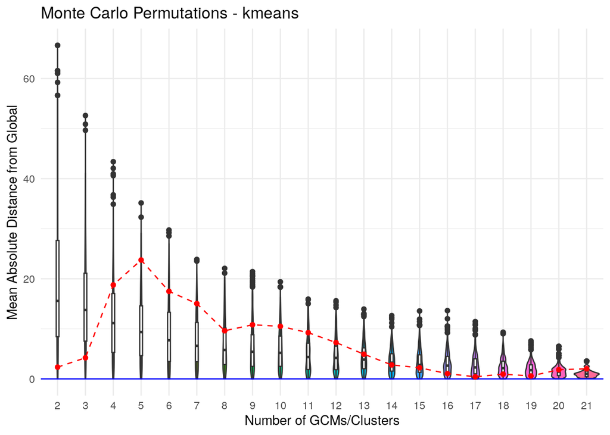

```
##
## $suggested_gcms
## $suggested_gcms$k2
##             1             2
## "CNRM-ESM2-1" "UKESM1-0-LL"
##
## $suggested_gcms$k3
##                  1                  2                  3
##      "CNRM-ESM2-1" "EC-Earth3-Veg-LR"      "UKESM1-0-LL"
##
## $suggested_gcms$k4
##               1               2               3               4
## "CanESM5-CanOE"   "CNRM-ESM2-1" "EC-Earth3-Veg"   "UKESM1-0-LL"
##
## $suggested_gcms$k5
##               1               2               3               4               5
## "CanESM5-CanOE"   "CNRM-ESM2-1" "EC-Earth3-Veg"   "UKESM1-0-LL"   "GISS-E2-1-G"
##
## $suggested_gcms$k6
##               1               2               3               4               5
##   "GISS-E2-1-G" "CNRM-CM6-1-HR" "MPI-ESM1-2-LR" "EC-Earth3-Veg" "CanESM5-CanOE"
##               6
##   "UKESM1-0-LL"
##
## $suggested_gcms$k7
##                 1                 2                 3                 4
##     "GISS-E2-1-G"       "CMCC-ESM2"     "CNRM-ESM2-1" "HadGEM3-GC31-LL"
##                 5                 6                 7
##   "EC-Earth3-Veg"   "MPI-ESM1-2-LR"   "CanESM5-CanOE"
##
## $suggested_gcms$k8
##                 1                 2                 3                 4
## "HadGEM3-GC31-LL"   "MPI-ESM1-2-LR"     "GISS-E2-1-G"       "CMCC-ESM2"
##                 5                 6                 7                 8
##   "CanESM5-CanOE"   "EC-Earth3-Veg"      "ACCESS-CM2"       "INM-CM4-8"
##
## $suggested_gcms$k9
##                 1                 2                 3                 4
##       "CMCC-ESM2"   "EC-Earth3-Veg"   "CanESM5-CanOE"   "MPI-ESM1-2-HR"
##                 5                 6                 7                 8
```

[output cut: 114 more lines]

```
##     "GISS-E2-1-G"      "CNRM-CM6-1"     "FIO-ESM-2-0"   "EC-Earth3-Veg"
##
## $suggested_gcms$k21
##                 1                 2                 3                 4
##   "ACCESS-ESM1-5"      "CNRM-CM6-1"   "MPI-ESM1-2-HR"   "CanESM5-CanOE"
##                 5                 6                 7                 8
##       "INM-CM5-0"      "ACCESS-CM2"      "MRI-ESM2-0"      "MIROC-ES2L"
##                 9                10                11                12
##     "CNRM-ESM2-1"     "GISS-E2-1-G"          "MIROC6"   "CNRM-CM6-1-HR"
##                13                14                15                16
##     "FIO-ESM-2-0"   "MPI-ESM1-2-LR" "HadGEM3-GC31-LL"    "IPSL-CM6A-LR"
##                17                18                19                20
##   "EC-Earth3-Veg"     "UKESM1-0-LL"       "CMCC-ESM2"     "GISS-E2-1-H"
##                21
##       "INM-CM4-8"
```

```r
tictoc::tic("K-means Clustering Temperature Variables")
mc_kmeans_temp <- montecarlo_gcms(s10,
                             var_names = c("bio1", "bio2", "bio3", "bio4", "bio5", "bio6", "bio7", "bio8", "bio9", "bio10", "bio11"),
                             study_area = study_area,
                             scale = TRUE,
                             perm = 10000,
                             dist_method = "euclidean",
                             clustering_method = "kmeans")
mc_kmeans_temp
```

```r
kmeans_temp <- mc_kmeans_temp$suggested_gcms$k5
tictoc::toc()
```

```
## K-means Clustering Temperature Variables: 31.99 sec elapsed
```

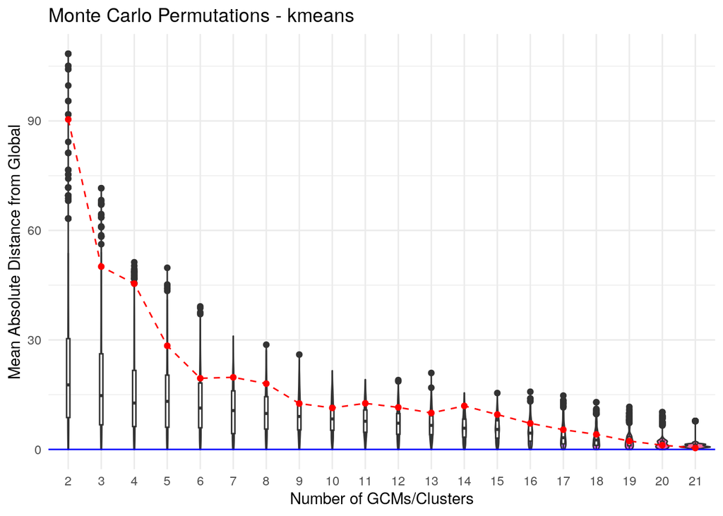

```
##
## $suggested_gcms
## $suggested_gcms$k2
##                 1                 2
##   "CanESM5-CanOE" "HadGEM3-GC31-LL"
##
## $suggested_gcms$k3
##               1               2               3
##        "MIROC6" "CanESM5-CanOE"   "UKESM1-0-LL"
##
## $suggested_gcms$k4
##                 1                 2                 3                 4
## "HadGEM3-GC31-LL"     "GISS-E2-1-G"   "EC-Earth3-Veg"   "CanESM5-CanOE"
##
## $suggested_gcms$k5
##                  1                  2                  3                  4
##      "CNRM-ESM2-1"           "MIROC6"      "GISS-E2-1-G"    "CanESM5-CanOE"
##                  5
## "EC-Earth3-Veg-LR"
##
## $suggested_gcms$k6
##                  1                  2                  3                  4
## "EC-Earth3-Veg-LR"      "CNRM-ESM2-1"    "CanESM5-CanOE"      "GISS-E2-1-G"
##                  5                  6
##           "MIROC6"  "HadGEM3-GC31-LL"
##
## $suggested_gcms$k7
##                  1                  2                  3                  4
##    "CanESM5-CanOE"      "CNRM-ESM2-1"    "MPI-ESM1-2-HR"           "MIROC6"
##                  5                  6                  7
## "EC-Earth3-Veg-LR"  "HadGEM3-GC31-LL"      "GISS-E2-1-G"
##
## $suggested_gcms$k8
##                 1                 2                 3                 4
##       "CMCC-ESM2"     "CNRM-ESM2-1"   "EC-Earth3-Veg"     "GISS-E2-1-G"
##                 5                 6                 7                 8
##   "CanESM5-CanOE"          "MIROC6"   "MPI-ESM1-2-HR" "HadGEM3-GC31-LL"
##
## $suggested_gcms$k9
##                 1                 2                 3                 4
```

[output cut: 116 more lines]

```
##      "MRI-ESM2-0"      "MIROC-ES2L"      "CNRM-CM6-1" "HadGEM3-GC31-LL"
##
## $suggested_gcms$k21
##                 1                 2                 3                 4
##   "MPI-ESM1-2-HR"       "CMCC-ESM2"      "MIROC-ES2L"     "UKESM1-0-LL"
##                 5                 6                 7                 8
##   "MPI-ESM1-2-LR"     "CNRM-ESM2-1"       "INM-CM5-0" "HadGEM3-GC31-LL"
##                 9                10                11                12
##          "MIROC6"     "FIO-ESM-2-0"   "CNRM-CM6-1-HR"   "EC-Earth3-Veg"
##                13                14                15                16
##      "ACCESS-CM2"       "INM-CM4-8"    "IPSL-CM6A-LR"      "MRI-ESM2-0"
##                17                18                19                20
##     "GISS-E2-1-H"      "CNRM-CM6-1"     "GISS-E2-1-G"   "ACCESS-ESM1-5"
##                21
##   "CanESM5-CanOE"
```

```r
tictoc::tic("K-means Clustering Precipitation Variables")
mc_kmeans_prec <- montecarlo_gcms(s10,
                             var_names = c("bio12", "bio13", "bio14", "bio15", "bio16", "bio17", "bio18", "bio19"),
                             study_area = study_area,
                             scale = TRUE,
                             perm = 10000,
                             dist_method = "euclidean",
                             clustering_method = "kmeans")
mc_kmeans_prec
```

```r
kmeans_prec <- mc_kmeans_prec$suggested_gcms$k5
tictoc::toc()
```

```
## K-means Clustering Precipitation Variables: 29.385 sec elapsed
```

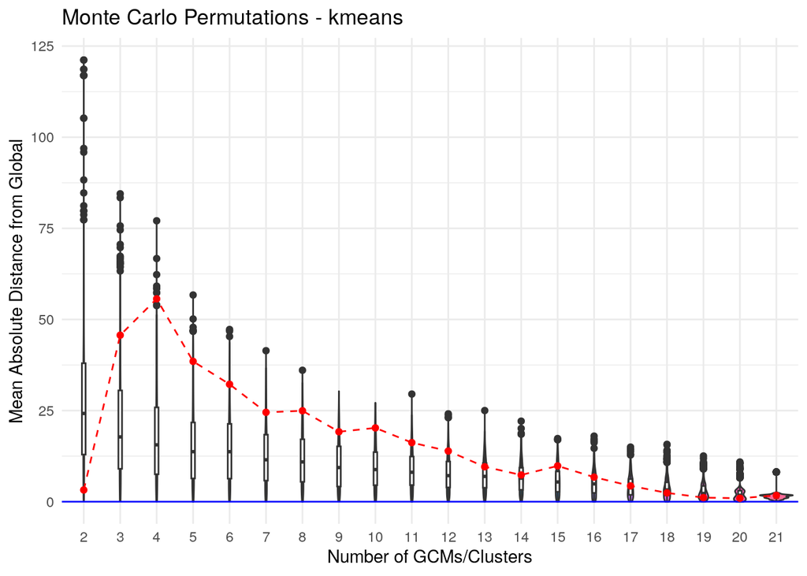

```
##
## $suggested_gcms
## $suggested_gcms$k2
##              1              2
## "IPSL-CM6A-LR"  "CNRM-ESM2-1"
##
## $suggested_gcms$k3
##               1               2               3
##   "UKESM1-0-LL"   "CNRM-ESM2-1" "CanESM5-CanOE"
##
## $suggested_gcms$k4
##                  1                  2                  3                  4
##      "GISS-E2-1-G" "EC-Earth3-Veg-LR"    "CanESM5-CanOE"      "CNRM-ESM2-1"
##
## $suggested_gcms$k5
##               1               2               3               4               5
##   "GISS-E2-1-G" "CanESM5-CanOE"   "UKESM1-0-LL"   "CNRM-ESM2-1" "EC-Earth3-Veg"
##
## $suggested_gcms$k6
##                 1                 2                 3                 4
##     "GISS-E2-1-G"     "CNRM-ESM2-1" "HadGEM3-GC31-LL"       "CMCC-ESM2"
##                 5                 6
##   "CanESM5-CanOE"   "EC-Earth3-Veg"
##
## $suggested_gcms$k7
##                 1                 2                 3                 4
##     "GISS-E2-1-G"   "EC-Earth3-Veg"     "FIO-ESM-2-0"       "CMCC-ESM2"
##                 5                 6                 7
##   "CanESM5-CanOE" "HadGEM3-GC31-LL"   "CNRM-CM6-1-HR"
##
## $suggested_gcms$k8
##                 1                 2                 3                 4
##       "CMCC-ESM2"   "CNRM-CM6-1-HR"     "FIO-ESM-2-0"     "GISS-E2-1-G"
##                 5                 6                 7                 8
##   "MPI-ESM1-2-HR"   "CanESM5-CanOE" "HadGEM3-GC31-LL"   "EC-Earth3-Veg"
##
## $suggested_gcms$k9
##                 1                 2                 3                 4
##      "MRI-ESM2-0"     "CNRM-ESM2-1"      "MIROC-ES2L"   "EC-Earth3-Veg"
##                 5                 6                 7                 8
```

[output cut: 114 more lines]

```
##     "FIO-ESM-2-0"       "INM-CM5-0"      "MIROC-ES2L"   "ACCESS-ESM1-5"
##
## $suggested_gcms$k21
##                 1                 2                 3                 4
##   "MPI-ESM1-2-LR"   "EC-Earth3-Veg"     "FIO-ESM-2-0"      "MIROC-ES2L"
##                 5                 6                 7                 8
##    "IPSL-CM6A-LR"   "MPI-ESM1-2-HR"      "MRI-ESM2-0"     "UKESM1-0-LL"
##                 9                10                11                12
##   "CanESM5-CanOE"       "INM-CM5-0"   "ACCESS-ESM1-5"     "GISS-E2-1-H"
##                13                14                15                16
##          "MIROC6"   "CNRM-CM6-1-HR"     "CNRM-ESM2-1"       "CMCC-ESM2"
##                17                18                19                20
##       "INM-CM4-8"      "CNRM-CM6-1"      "ACCESS-CM2" "HadGEM3-GC31-LL"
##                21
##     "GISS-E2-1-G"
```

```r
tictoc::tic("K-means Clustering All Variables")
mc_kmeans_all <- montecarlo_gcms(s10,
                             var_names = "all",
                             study_area = study_area,
                             scale = TRUE,
                             perm = 10000,
                             dist_method = "euclidean",
                             clustering_method = "kmeans")
mc_kmeans_all
```

```r
kmeans_all <- mc_kmeans_all$suggested_gcms$k5
tictoc::toc()
```

```
## K-means Clustering All Variables: 39.324 sec elapsed
```

### Closestdist selection

```r
tictoc::tic("Closestdist Main Variables")
mc_closestdist_main <- closestdist_gcms(s10,
                             var_names = c("bio1", "bio12"),
                             study_area = study_area,
                             method = "euclidean")
```

```
## CRS from s and study_area are not identical. Reprojecting study area.
```

```r
mc_closestdist_main
```

```
## $suggested_gcms
## [1] "CNRM-CM6-1"    "MPI-ESM1-2-HR" "MPI-ESM1-2-LR" "MIROC-ES2L"
## [5] "MIROC6"        "INM-CM5-0"
##
## $best_mean_diff
## [1] 0.0008346833
##
## $global_mean
## [1] 38.9711
```

```r
closestdist_main <- mc_closestdist_main$suggested_gcms
tictoc::toc()
```

```
## Closestdist Main Variables: 2.326 sec elapsed
```

```r
tictoc::tic("Closestdist Temperature Variables")
mc_closestdist_temp <- closestdist_gcms(s10,
                             var_names = c("bio1", "bio2", "bio3", "bio4", "bio5", "bio6", "bio7", "bio8", "bio9", "bio10", "bio11"),
                             study_area = study_area,
                             method = "euclidean")
```

```
## CRS from s and study_area are not identical. Reprojecting study area.
```

```r
mc_closestdist_temp
```

```
## $suggested_gcms
## [1] "CMCC-ESM2"        "EC-Earth3-Veg-LR" "HadGEM3-GC31-LL"  "CNRM-CM6-1-HR"
## [5] "INM-CM4-8"
##
## $best_mean_diff
## [1] 0.001303225
##
## $global_mean
## [1] 118.7889
```

```r
closestdist_temp <- mc_closestdist_temp$suggested_gcms
tictoc::toc()
```

```
## Closestdist Temperature Variables: 3.732 sec elapsed
```

```r
tictoc::tic("Closestdist Precipitation Variables")
mc_closestdist_prec <- closestdist_gcms(s10,
                             var_names = c("bio12", "bio13", "bio14", "bio15", "bio16", "bio17", "bio18", "bio19"),
                             study_area = study_area,
                             method = "euclidean")
```

```
## CRS from s and study_area are not identical. Reprojecting study area.
```

```r
mc_closestdist_prec
```

```
## $suggested_gcms
## [1] "CNRM-CM6-1"  "GISS-E2-1-G" "MRI-ESM2-0"  "UKESM1-0-LL" "GISS-E2-1-H"
##
## $best_mean_diff
## [1] 0.0009509144
##
## $global_mean
## [1] 115.8417
```

```r
closestdist_prec <- mc_closestdist_prec$suggested_gcms
tictoc::toc()
```

```
## Closestdist Precipitation Variables: 2.939 sec elapsed
```

```r
tictoc::tic("Closestdist All Variables")
mc_closestdist_all <- closestdist_gcms(s10,
                             var_names = "all",
                             study_area = study_area,
                             method = "euclidean")
```

```
## CRS from s and study_area are not identical. Reprojecting study area.
```

```r
mc_closestdist_all
```

```
## $suggested_gcms
## [1] "EC-Earth3-Veg" "MIROC6"        "UKESM1-0-LL"
##
## $best_mean_diff
## [1] 0.003716754
##
## $global_mean
## [1] 166.5351
```

```r
closestdist_all <- mc_closestdist_all$suggested_gcms
tictoc::toc()
```

```
## Closestdist All Variables: 4.7 sec elapsed
```

### Closestdist selection with fixed k

```r
tictoc::tic("Closestdist3 Main Variables")
mc_closestdist3_main <- closestdist_gcms(s10,
                             var_names = c("bio1", "bio12"),
                             study_area = study_area,
                             method = "euclidean",
                             k = 3)
```

```
## CRS from s and study_area are not identical. Reprojecting study area.
```

```r
mc_closestdist3_main
```

```
## $suggested_gcms
## [1] "ACCESS-ESM1-5" "CNRM-CM6-1"    "FIO-ESM-2-0"
##
## $best_mean_diff
## [1] 0.003674818
##
## $global_mean
## [1] 38.9711
```

```r
closestdist3_main <- mc_closestdist3_main$suggested_gcms
tictoc::toc()
```

```
## Closestdist3 Main Variables: 2.203 sec elapsed
```

```r
tictoc::tic("Closestdist3 Temperature Variables")
mc_closestdist3_temp <- closestdist_gcms(s10,
                             var_names = c("bio1", "bio2", "bio3", "bio4", "bio5", "bio6", "bio7", "bio8", "bio9", "bio10", "bio11"),
                             study_area = study_area,
                             method = "euclidean",
                             k = 3)
```

```
## CRS from s and study_area are not identical. Reprojecting study area.
```

```r
mc_closestdist3_temp
```

```
## $suggested_gcms
## [1] "CNRM-CM6-1-HR"   "GISS-E2-1-H"     "HadGEM3-GC31-LL"
##
## $best_mean_diff
## [1] 0.006257591
##
## $global_mean
## [1] 118.7889
```

```r
closestdist3_temp <- mc_closestdist3_temp$suggested_gcms
tictoc::toc()
```

```
## Closestdist3 Temperature Variables: 3.07 sec elapsed
```

```r
tictoc::tic("Closestdist3 Precipitation Variables")
mc_closestdist3_prec <- closestdist_gcms(s10,
                             var_names = c("bio12", "bio13", "bio14", "bio15", "bio16", "bio17", "bio18", "bio19"),
                             study_area = study_area,
                             method = "euclidean",
                             k = 3)
```

```
## CRS from s and study_area are not identical. Reprojecting study area.
```

```r
mc_closestdist3_prec
```

```
## $suggested_gcms
## [1] "EC-Earth3-Veg-LR" "INM-CM5-0"        "IPSL-CM6A-LR"
##
## $best_mean_diff
## [1] 0.002350225
##
## $global_mean
## [1] 115.8417
```

```r
closestdist3_prec <- mc_closestdist3_prec$suggested_gcms
tictoc::toc()
```

```
## Closestdist3 Precipitation Variables: 3.334 sec elapsed
```

```r
tictoc::tic("Closestdist3 All Variables")
mc_closestdist3_all <- closestdist_gcms(s10,
                             var_names = "all",
                             study_area = study_area,
                             method = "euclidean",
                             k = 3)
```

```
## CRS from s and study_area are not identical. Reprojecting study area.
```

```r
mc_closestdist3_all
```

```
## $suggested_gcms
## [1] "EC-Earth3-Veg" "MIROC6"        "UKESM1-0-LL"
##
## $best_mean_diff
## [1] 0.003716754
##
## $global_mean
## [1] 166.5351
```

```r
closestdist3_all <- mc_closestdist3_all$suggested_gcms
tictoc::toc()
```

```
## Closestdist3 All Variables: 3.936 sec elapsed
```

## Results

```r
table(c(hclust_main, hclust_temp, hclust_prec, hclust_all))
```

```
##
##       ACCESS-CM2    ACCESS-ESM1-5    CanESM5-CanOE        CMCC-ESM2
##                1                1                3                3
##       CNRM-CM6-1 EC-Earth3-Veg-LR      FIO-ESM-2-0      GISS-E2-1-G
##                2                3                2                1
##      GISS-E2-1-H    MPI-ESM1-2-HR       MRI-ESM2-0
##                2                1                1
```

```r
table(c(kmeans_main, kmeans_temp, kmeans_prec, kmeans_all))
```

```
##
##    CanESM5-CanOE       CNRM-CM6-1      CNRM-ESM2-1    EC-Earth3-Veg
##                4                1                3                2
## EC-Earth3-Veg-LR      GISS-E2-1-G           MIROC6    MPI-ESM1-2-HR
##                1                3                1                1
##       MRI-ESM2-0      UKESM1-0-LL
##                1                3
```

```r
table(c(closestdist_main, closestdist_temp, closestdist_prec, closestdist_all))
```

```
##
##        CMCC-ESM2       CNRM-CM6-1    CNRM-CM6-1-HR    EC-Earth3-Veg
##                1                2                1                1
## EC-Earth3-Veg-LR      GISS-E2-1-G      GISS-E2-1-H  HadGEM3-GC31-LL
##                1                1                1                1
##        INM-CM4-8        INM-CM5-0       MIROC-ES2L           MIROC6
##                1                1                1                2
##    MPI-ESM1-2-HR    MPI-ESM1-2-LR       MRI-ESM2-0      UKESM1-0-LL
##                1                1                1                2
```

```r
table(c(closestdist3_main, closestdist3_temp, closestdist3_prec, closestdist3_all))
```

```
##
##    ACCESS-ESM1-5       CNRM-CM6-1    CNRM-CM6-1-HR    EC-Earth3-Veg
##                1                1                1                1
## EC-Earth3-Veg-LR      FIO-ESM-2-0      GISS-E2-1-H  HadGEM3-GC31-LL
##                1                1                1                1
##        INM-CM5-0     IPSL-CM6A-LR           MIROC6      UKESM1-0-LL
##                1                1                1                1
```